# Duygu Analizi

Buse Demir

11 09 2022

## VERİ OKUMA

```
## # A tibble: 6 x 6
##   AuthorID Author        Date     Content                 Attachments Reactions
##      <dbl> <chr>         <chr>    <chr>                   <chr>       <chr>
## 1  7.99e17 "Kingpin#829~ 1.03.20~ "As bad a FiG are for ~ <NA>        "\U0001f4~
## 2  9.16e17 "moyo.y.yo#2~ 1.03.20~ "Alguien sabe cuándo e~ <NA>         <NA>
## 3  1.39e17 "Dylan#2534"  1.03.20~ "im referring to them ~ <NA>         <NA>
## 4  3.60e17 "ggmagalhaes~ 1.03.20~ "ya empezó, manito"     <NA>         <NA>
## 5  3.60e17 "ggmagalhaes~ 1.03.20~ "hoy 00:00 UTC"         <NA>         <NA>
## 6  7.50e17 "luke1 (\U00~ 1.03.20~ "@NPLUS_JAY @blak3 bro~ <NA>         <NA>
```

## VERİ ÖNİŞLEME

### Tarih ve Saat sütunlarını Ayırma

```
## # A tibble: 6 x 7
##   AuthorID Author       DATE   TIME  Content              Attachments Reactions
##      <dbl> <chr>        <chr>  <chr> <chr>                <chr>       <chr>
## 1  7.99e17 "Kingpin#82~ 1.03.~ 00:04 "As bad a FiG are f~ <NA>        "\U0001f4~
## 2  9.16e17 "moyo.y.yo#~ 1.03.~ 00:07 "Alguien sabe cuánd~ <NA>         <NA>
## 3  1.39e17 "Dylan#2534" 1.03.~ 00:08 "im referring to th~ <NA>         <NA>
## 4  3.60e17 "ggmagalhae~ 1.03.~ 00:23 "ya empezó, manito"  <NA>         <NA>
## 5  3.60e17 "ggmagalhae~ 1.03.~ 00:23 "hoy 00:00 UTC"      <NA>         <NA>
## 6  7.50e17 "luke1 (\U0~ 1.03.~ 00:39 "@NPLUS_JAY @blak3 ~ <NA>         <NA>
```

## Fiyat Verisi Analizi

```r
head(price_new)
```

```
## # A tibble: 6 x 2
##   DATE       price
##   <chr>      <dbl>
## 1 2022-03-01  1.88
## 2 2022-03-02  1.95
## 3 2022-03-03  1.86
## 4 2022-03-04  1.88
## 5 2022-03-05  1.74
## 6 2022-03-06  1.77
```

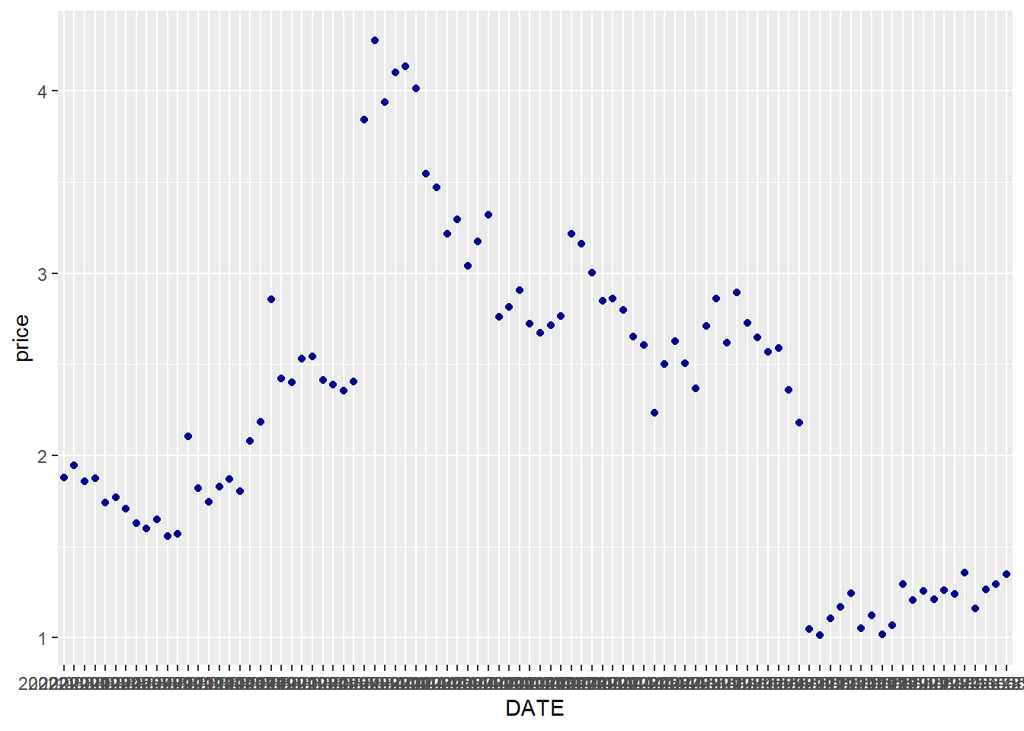

```r
h1<-price_new %>%
ggplot(aes(x=DATE, y=price))+geom_point(col="darkblue")
h1
```

#### 1 marttan itibaren düşüşte olan *price* değeri 13 martta 1.56 dan 2.10 değerine çıkmış. 14 martta tekrar düşüşe geçtikten sonra artış göstermeye başlamıştır.21 martta 2.18 den 2.85 değerine çıkmış ve tekrar 2.40 değerlerine inmiştir. 29 Martta 2.40 olan *price* değerinin ani bir artışla 3.84 değerine ulaştığı görülmektedir.Bu tarihten sonra arada küçük artışlar yaşansa da düşüşe geçtiği görülen *price* değeri 12 mayıs tarihinde 2.17 değerinden 1.04 e ani bir düşüş yaşamıştır.

### ÖNEMLİ TARİHLER

#### 30 Mart (Ani yükselme)

#### 12 Mayıs (Ani düşüş)

### Grafiği 3 farklı dönem içinde inceleme

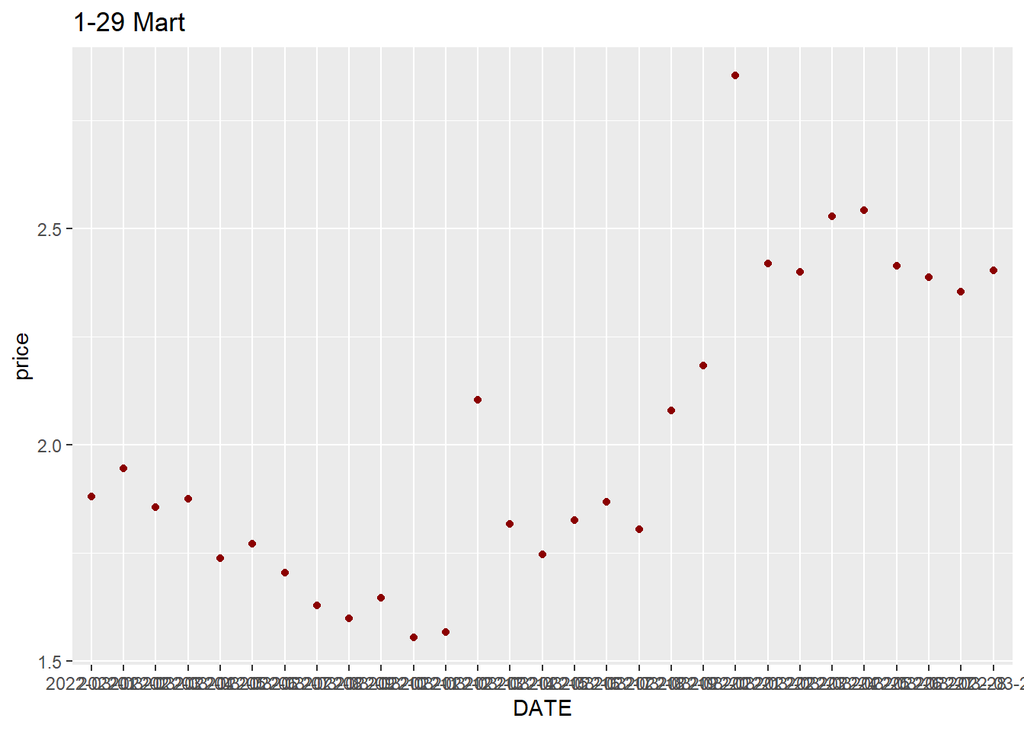

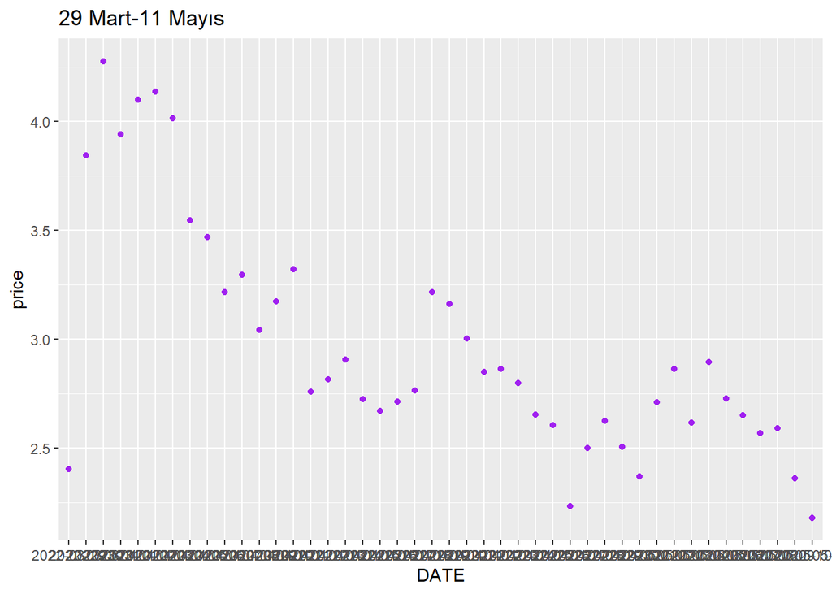

#### 29 martta 2.40 olan *price* 30 martta 3.84’e yükselmiş ve bu tarihten sonra ara ara artışa geçse de düşmeye başlamıştır.19 nisanda 2.76 dan 3.21 e yükselip tekrar düşüşe geçmiş.

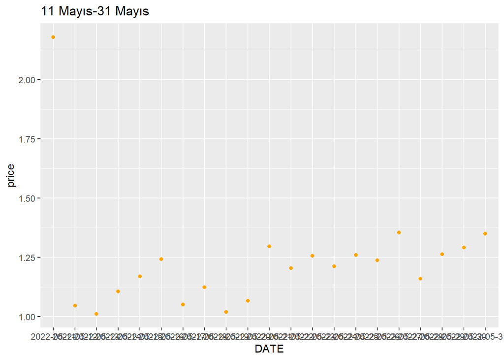

#### 12 mayısta 2.17 den 1.04 e düşmüş ve bu tarihten sonra belirli bir düşüş ya da artış yaşamamıştır.

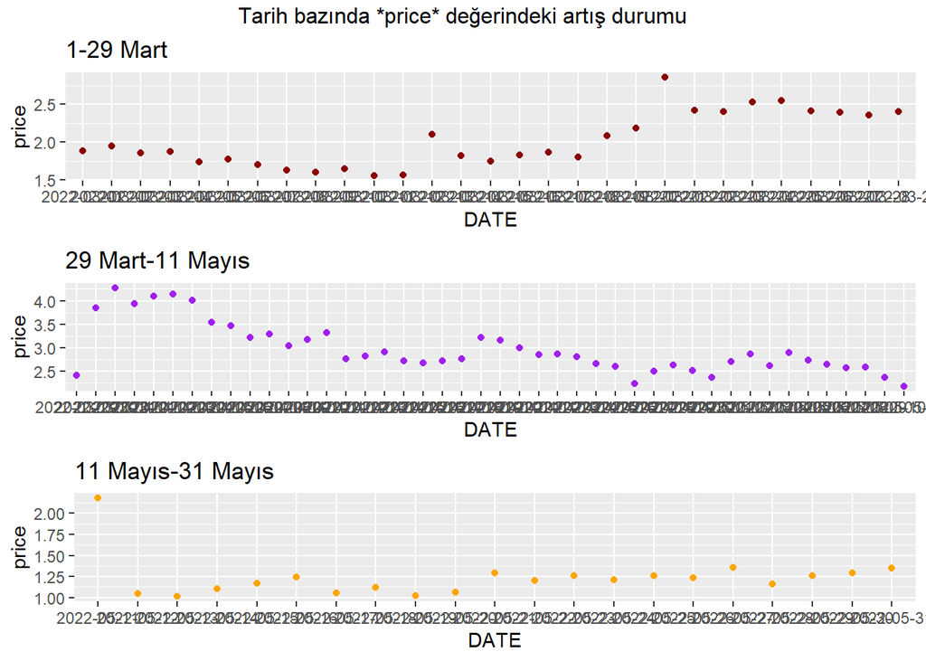

### 1 Mart-30 Mayıs aralığındaki veriler

#### Veri seti 1 Mart 31 Mayıs aralığındaki mesajları içerecek şekilde filtrelenmiş ve kayıp değerler veriden çıkarılmıştır.

```r
head(price_new)
```

```
## # A tibble: 6 x 2
##   DATE       price
##   <chr>      <dbl>
## 1 2022-03-01  1.88
## 2 2022-03-02  1.95
## 3 2022-03-03  1.86
## 4 2022-03-04  1.88
## 5 2022-03-05  1.74
## 6 2022-03-06  1.77
```

```r
head(discord_msg)
```

```
## # A tibble: 6 x 3
##   DATE      TIME  Content
##   <chr>     <chr> <chr>
## 1 1.03.2022 00:04 "As bad a FiG are for it, they are like entry level botters c~
## 2 1.03.2022 00:07 "Alguien sabe cuándo empieza el Cvc?"
## 3 1.03.2022 00:08 "im referring to them using the multi equipment glitch to tak~
## 4 1.03.2022 00:23 "ya empezó, manito"
## 5 1.03.2022 00:23 "hoy 00:00 UTC"
## 6 1.03.2022 00:39 "@NPLUS_JAY @blak3 bro, can you help me?\ni write ticket\npro~
```

### İngilizcede “the, is, at, on” gibi kelimeler durdurma sözcükleri (stop-words) olarak bilinir ve bir dilde en sık rastlanan sözcüklerdir. Bu ve benzeri kelimeler metinden yararlı bilgiler çıkarma açısından çok az değere sahiptir. Analizden önce metindeki bu kelimeleri kaldırmamız gerekir.Ayrıca daha sağlıklı bir analiz için metinde geçen noktalama işaretleri, rakamlar ve linkler çıkarılmıştır.

```r
corpus <- iconv(discord_msg$Content)
corpus<- Corpus(VectorSource(corpus))
corpus <- tm_map(corpus, tolower) # Büyük harfleri küçük yapma
```

### Terim sıklığı (TF)

```r
removeURL<- function(x) gsub('http[[:alnum:]]*', '', x)
cleanset<- tm_map(cleanset, content_transformer(removeURL))## linkleri silme
corpus <- tm_map(cleanset, stemDocument)
dtm <- DocumentTermMatrix(corpus)
inspect(dtm)
```

```
## <<DocumentTermMatrix (documents: 79804, terms: 19853)>>
## Non-/sparse entries: 413236/1583935576
## Sparsity           : 100%
## Maximal term length: 211
## Weighting          : term frequency (tf)
## Sample             :
##        Terms
## Docs    account ban bot can dont game get just like will
##   25473       3   1   0   0    0    6   1    0    1    0
##   25889       0   0   0   3    2    6   0    0    0    1
##   3558        1   0   0   0    0    4   0    0    3    0
##   45981       0   0   0   2    0    0   0    0    0    2
##   47068       1   1   1   4    1    4   0    0    2    1
##   60197       0   0   0   1    0    2   1    0    0    0
##   60380       0   0   0   1    0    2   1    0    0    0
##   63658       2   2   1   0    1    3   0    0    0    2
##   70945       0   1   0   1    0    3   1    0    0    0
##   72748       1   1   0   1    1    4   0    2    3    0
```

#### Mesajlarda geçen kelimelerin frekansları (1 mart-29 mart)

```r
corpus_1 <- tm_map(cleanset_1, stemDocument)
tdm_1 <- TermDocumentMatrix(corpus_1)
tdm_1 <- as.matrix(tdm_1)
tdm_1[1:10, 1:20]
```

```
##          Docs
## Terms     1 2 3 4 5 6 7 8 9 10 11 12 13 14 15 16 17 18 19 20
##   allianc 1 0 0 0 0 0 0 0 0  0  0  0  0  0  0  0  0  0  0  0
##   around  1 0 0 0 0 0 0 0 0  0  0  0  0  0  0  0  0  0  0  0
##   bad     1 0 0 0 0 0 0 0 0  0  0  0  0  0  0  0  0  0  0  0
##   bigger  1 0 0 0 0 0 0 0 0  0  0  0  0  0  0  0  0  0  0  0
##   bot     1 0 0 0 0 0 0 0 0  0  0  0  0  0  0  0  0  0  0  0
##   botter  1 0 0 0 0 0 0 0 0  0  0  0  0  0  0  0  0  0  0  0
##   built   1 0 0 0 0 0 0 0 0  0  0  0  0  0  0  0  0  0  0  0
##   cheat   1 0 0 0 0 0 0 0 0  0  0  0  0  0  0  0  0  0  0  0
##   compar  1 0 0 0 0 0 0 0 0  0  0  0  0  0  0  0  0  0  0  0
##   develop 1 0 0 0 0 0 0 0 0  0  0  0  0  0  0  0  0  0  0  0
```

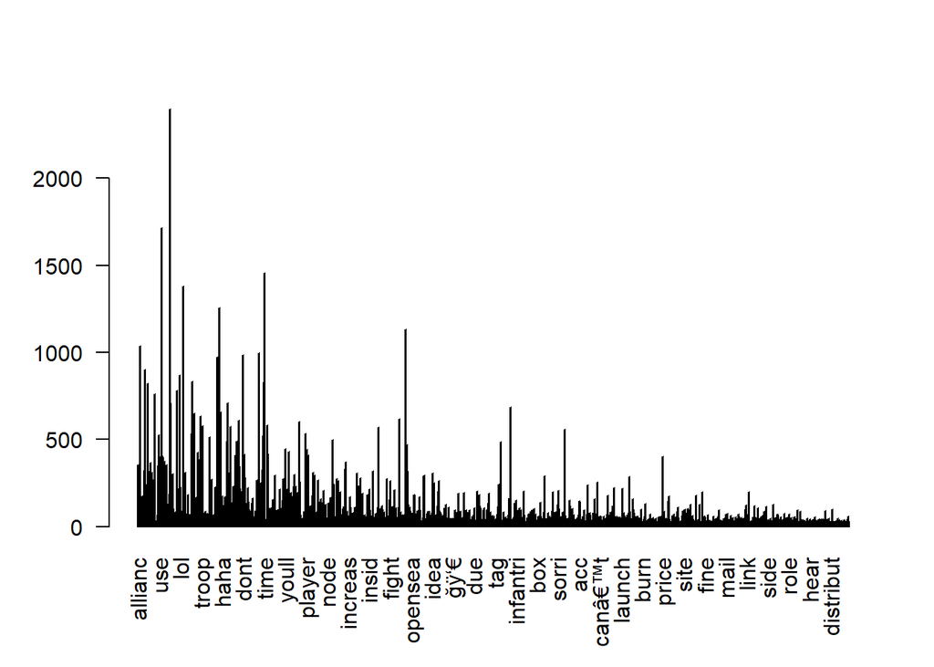

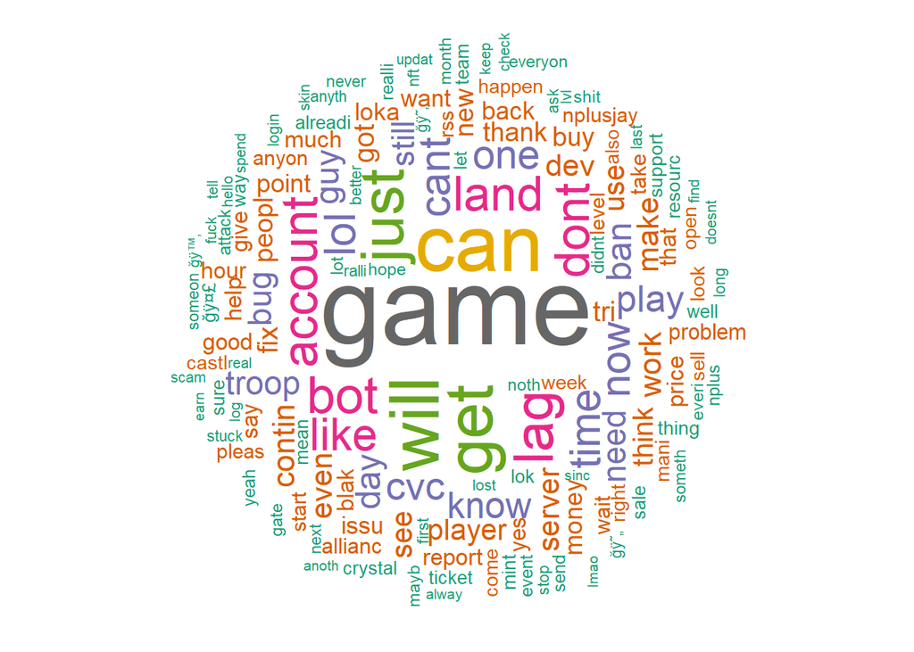

### 29 mart-11 mayıs

#### Mesajlarda geçen kelimelerin frekansları (29 mart-11 mayıs)

```
##         Docs
## Terms    1 2 3 4 5 6 7 8 9 10 11 12 13 14 15 16 17 18 19 20
##   caus   1 0 0 0 0 0 0 0 0  0  0  0  0  0  0  0  0  0  0  0
##   first  1 0 0 0 0 0 0 0 0  0  0  0  0  0  0  0  0  0  0  0
##   kucoin 1 0 0 0 0 0 0 0 0  0  0  0  0  0  0  0  0  0  0  0
##   later  1 0 0 0 0 0 0 0 0  0  0  0  0  0  0  0  0  0  0  0
##   one    1 0 0 0 0 1 0 0 0  0  0  0  0  0  0  0  0  0  0  0
##   pump   1 0 0 0 0 0 0 0 0  0  0  0  0  0  0  0  0  0  0  0
##   think  1 0 0 0 0 0 0 0 0  0  0  0  0  1  0  0  0  0  0  0
##   yes    0 1 0 0 0 0 0 0 0  0  0  0  0  0  0  0  0  0  0  0
##   forget 0 0 0 1 0 0 0 0 0  0  0  0  0  0  0  0  0  0  0  0
##   grow   0 0 0 1 0 0 0 0 0  0  0  0  0  0  0  0  0  0  0  0
```

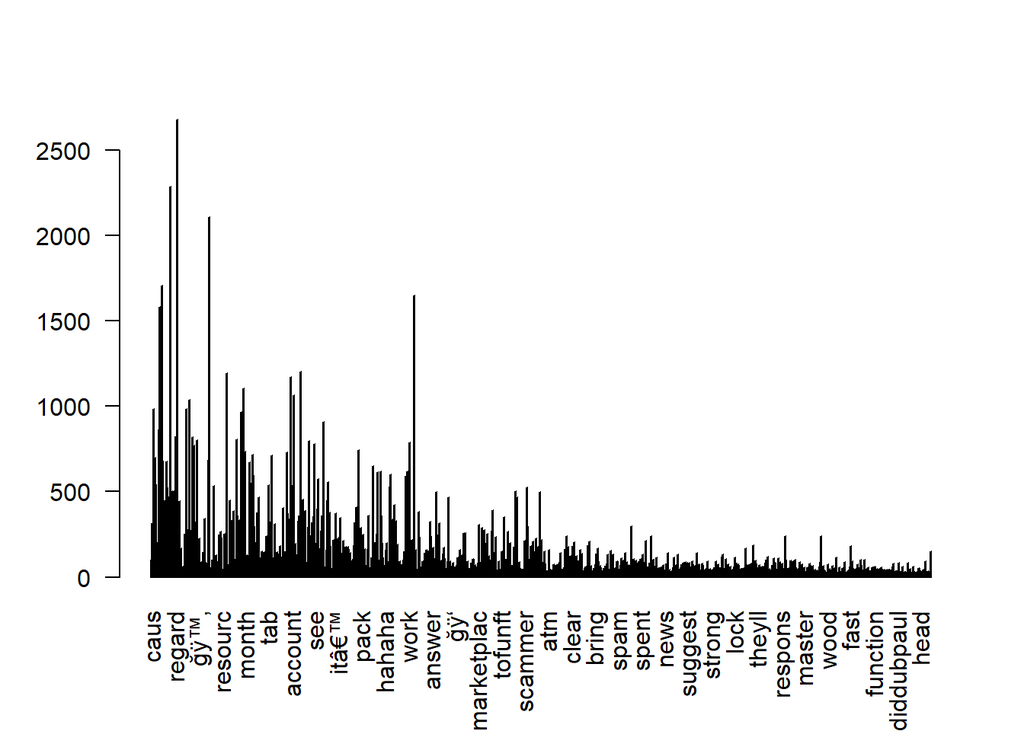

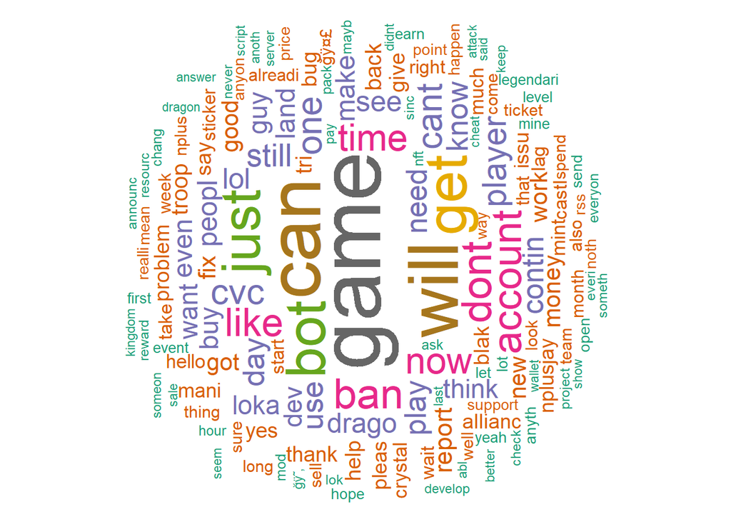

### Duygu Analizi

#### Duygu analizinde duygular pozitif, negatif ve nötr olmak üzere 3 genel başlık altında sınıflandırılır. Ayrıca, bir metinde yer alan duygunun pozitif veya negatif gücünün derecesi sayısal bir ölçekte temsil edilebilir.Bu çalışmada 4 farklı duygu sözlüğüne sahip olan R’ın hazır paketleriden *syuzhet* paketinden yararlanılmıştır.

```
## # A tibble: 6,786 x 2
##    word        sentiment
##    <chr>       <chr>
##  1 2-faces     negative
##  2 abnormal    negative
##  3 abolish     negative
##  4 abominable  negative
##  5 abominably  negative
##  6 abominate   negative
##  7 abomination negative
##  8 abort       negative
##  9 aborted     negative
## 10 aborts      negative
## # ... with 6,776 more rows
```

```
## # A tibble: 2,477 x 2
##    word       value
##    <chr>      <dbl>
##  1 abandon       -2
##  2 abandoned     -2
##  3 abandons      -2
##  4 abducted      -2
##  5 abduction     -2
##  6 abductions    -2
##  7 abhor         -3
##  8 abhorred      -3
##  9 abhorrent     -3
## 10 abhors        -3
## # ... with 2,467 more rows
```

```
## # A tibble: 13,875 x 2
##    word        sentiment
##    <chr>       <chr>
##  1 abacus      trust
##  2 abandon     fear
##  3 abandon     negative
##  4 abandon     sadness
##  5 abandoned   anger
##  6 abandoned   fear
##  7 abandoned   negative
##  8 abandoned   sadness
##  9 abandonment anger
## 10 abandonment fear
## # ... with 13,865 more rows
```

### En çok kullanılan kelimeler

```r
cleandata<-data_word
cleandata<-cleandata %>% anti_join(stop_words)
cleandata %>% dplyr::count(word,sort=TRUE)
```

```
## # A tibble: 29,305 x 2
##    word          n
##    <chr>     <int>
##  1 ı         13554
##  2 game       6488
##  3 https      3506
##  4 account    2604
##  5 view       2409
##  6 gif        2407
##  7 tenor.com  2353
##  8 lol        2342
##  9 cvc        2303
## 10 time       2294
## # ... with 29,295 more rows
```

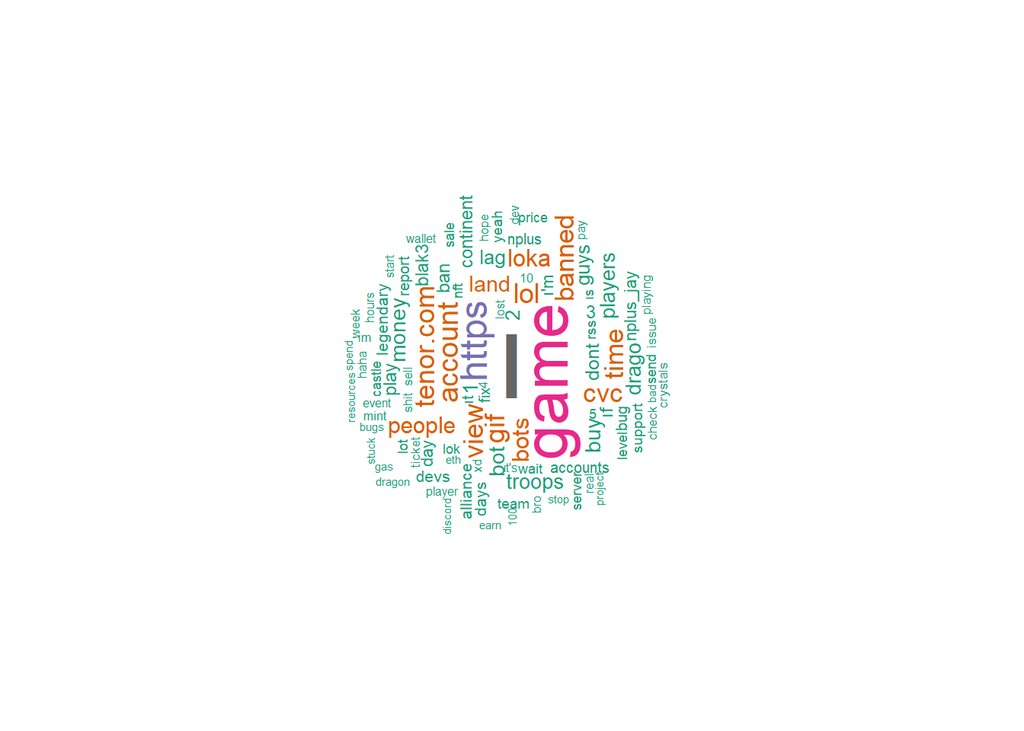

### Pozitif/Negatif kelimelerin ayrıldığı kelime bulutu

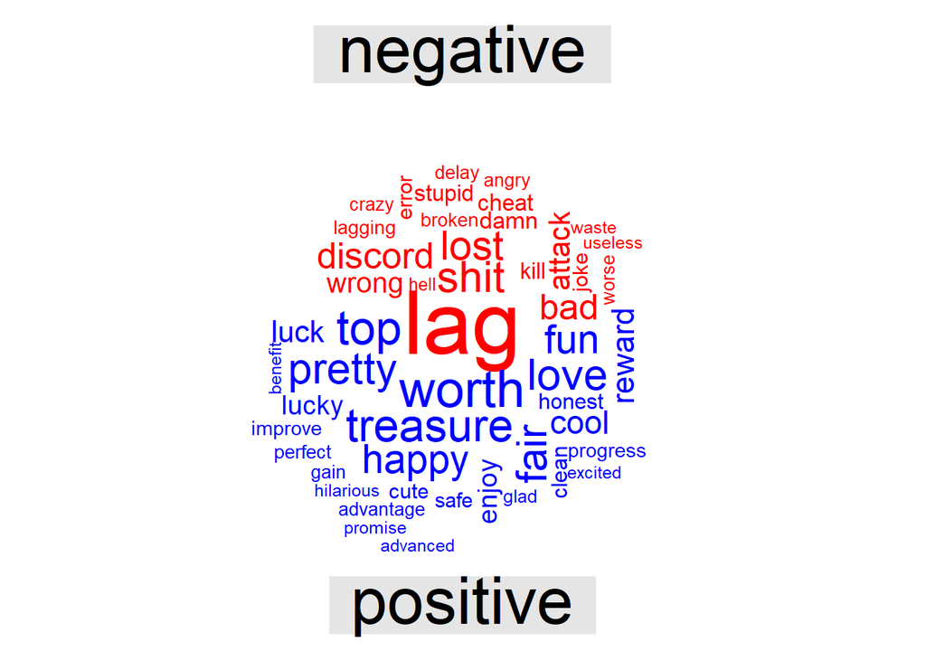

```r
sentiments<-cleandata %>%inner_join(get_sentiments("bing"))%>% dplyr::count(word,sentiment,sort=TRUE)
head(sentiments)
```

```
## # A tibble: 6 x 3
##   word      sentiment     n
##   <chr>     <chr>     <int>
## 1 lag       negative   1492
## 2 legendary positive    995
## 3 bug       negative    894
## 4 support   positive    880
## 5 issue     negative    660
## 6 shit      negative    624
```

```r
sentiment_pos<-subset(sentiments,sentiment=="positive")
sentiment_neg<-subset(sentiments,sentiment=="negative")
```

```r
set.seed(2022)
positive_score<-aggregate(n~sentiment,data=sentiment_pos,sum)
negative_score<-aggregate(n~sentiment,data=sentiment_neg,sum)
ratio<-(positive_score$n/negative_score$n) ## %54 pozitif duygular ağırlıklı
```

## Belirli bir dönem için

```r
get_sentiments("bing") # negatif pozitif
```

```
## # A tibble: 6,786 x 2
##    word        sentiment
##    <chr>       <chr>
##  1 2-faces     negative
##  2 abnormal    negative
##  3 abolish     negative
##  4 abominable  negative
##  5 abominably  negative
##  6 abominate   negative
##  7 abomination negative
##  8 abort       negative
##  9 aborted     negative
## 10 aborts      negative
## # ... with 6,776 more rows
```

```r
get_sentiments("afinn") # -5 5 arası
```

```
## # A tibble: 2,477 x 2
##    word       value
##    <chr>      <dbl>
##  1 abandon       -2
##  2 abandoned     -2
##  3 abandons      -2
##  4 abducted      -2
##  5 abduction     -2
##  6 abductions    -2
##  7 abhor         -3
##  8 abhorred      -3
##  9 abhorrent     -3
## 10 abhors        -3
## # ... with 2,467 more rows
```

```r
get_sentiments("nrc") # kelimelrin içerdiği duygular fear happy anger
```

```
## # A tibble: 13,875 x 2
##    word        sentiment
##    <chr>       <chr>
##  1 abacus      trust
##  2 abandon     fear
##  3 abandon     negative
##  4 abandon     sadness
##  5 abandoned   anger
##  6 abandoned   fear
##  7 abandoned   negative
##  8 abandoned   sadness
##  9 abandonment anger
## 10 abandonment fear
## # ... with 13,865 more rows
```

```r
discord_date<-discord_msg[c(27410:31920),]
text_date_new<-discord_date[,-c(1,2)] # sadece text içeren sütun kaldı
data_word<-text_date_new %>% dplyr:: mutate(linenumber=row_number())%>% unnest_tokens(word,Content) # cümleler  kelimeler halinde ayrılmıştır.

word<-c('ı',"ı'm" ,"ı'll","ı'd","ıs","ıt", "ıf", "ım","im","1","2","3","4","5","10","100", "https","lol","ıt's","ım","haha","tho","fuck","fucked","fcked","fucking","fucks","fuckup","dick",'shit',"shitty","bullshit","shittiest","fuckıng","fuckın","fuckin","fucker","fuck.gif","motherfucker","bitches","bitching", "bitch","damn")
lexicon<-c("CURSE","CURSE","CURSE","CURSE","CURSE","CURSE","CURSE","CURSE","CURSE","CURSE","CURSE","CURSE","CURSE","CURSE","CURSE","CURSE","CURSE","CURSE","CURSE","CURSE","CURSE","CURSE","CURSE","CURSE","CURSE","CURSE","CURSE","CURSE","CURSE","CURSE","CURSE","CURSE","CURSE","CURSE","CURSE","CURSE","CURSE","CURSE","CURSE","CURSE","CURSE","CURSE","CURSE") #Küfürler ve sözlükte olmayan bazı kelimeler stop_word sözlüğündeki kelimelerle birlikte çıkarılmıştır
curse_words<-data.frame(word,lexicon)
stop_words_curse<-rbind(stop_words,curse_words)
```

### En çok kullanılan kelimeler

```r
cleandata<-data_word
cleandata<-cleandata %>% anti_join(stop_words)
cleandata %>% dplyr::count(word,sort=TRUE)
```

```
## # A tibble: 4,710 x 2
##    word          n
##    <chr>     <int>
##  1 ı           786
##  2 game        321
##  3 https       219
##  4 cvc         134
##  5 gif         130
##  6 tenor.com   129
##  7 view        129
##  8 land        127
##  9 account     124
## 10 lol         118
## # ... with 4,700 more rows
```

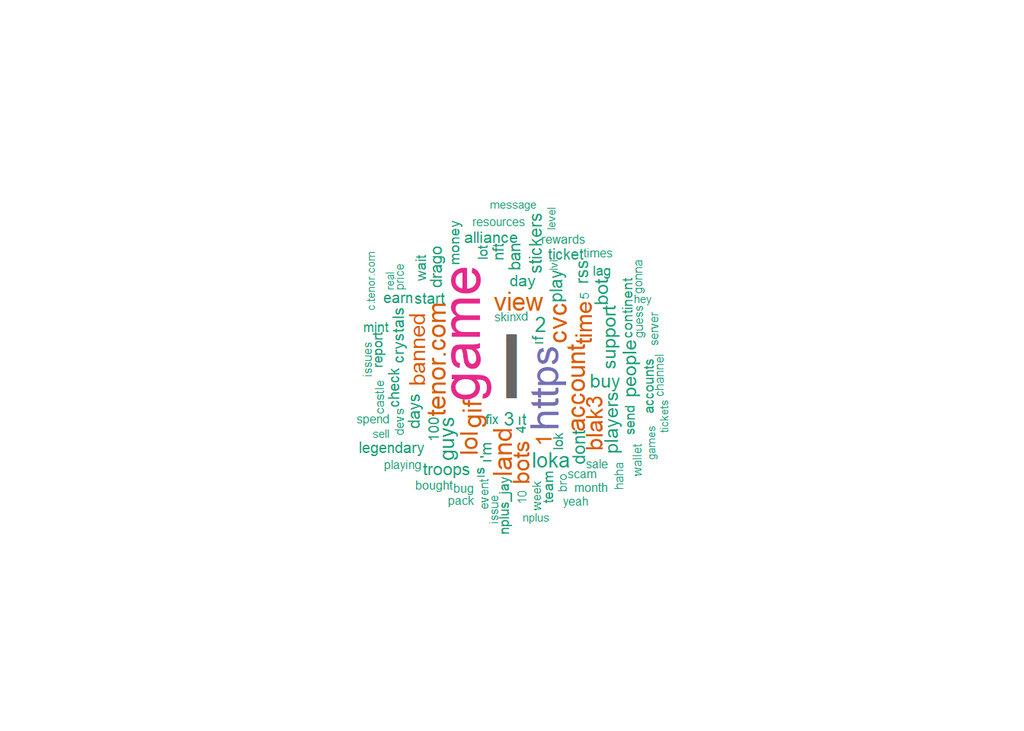

### Pozitif/Negatif kelimelerin ayrıldığı kelime bulutu

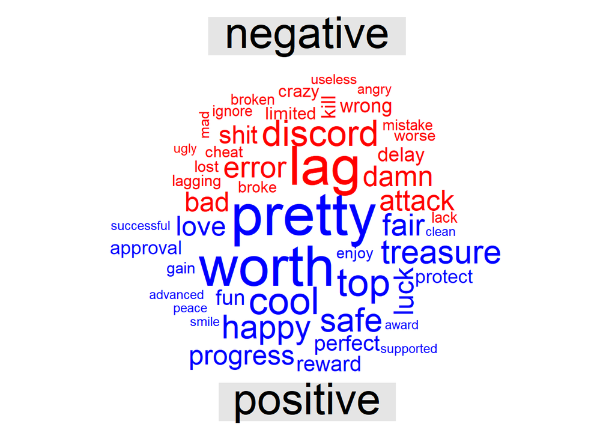

```r
sentiments<-cleandata %>%inner_join(get_sentiments("bing"))%>% dplyr:: count(word,sentiment,sort=TRUE)
head(sentiments)
```

```
## # A tibble: 6 x 3
##   word      sentiment     n
##   <chr>     <chr>     <int>
## 1 support   positive     80
## 2 legendary positive     52
## 3 lag       negative     42
## 4 bug       negative     39
## 5 scam      negative     36
## 6 issue     negative     33
```

```r
sentiment_pos<-subset(sentiments,sentiment=="positive")
sentiment_neg<-subset(sentiments,sentiment=="negative")
```

```r
set.seed(2022)
positive_score<-aggregate(n~sentiment,data=sentiment_pos,sum)
negative_score<-aggregate(n~sentiment,data=sentiment_neg,sum)
ratio<-(positive_score$n/negative_score$n) ## %61 pozitif duygular ağırlıklı
```

## Belirli bir dönem için

#### 12 mayıs 20 mayıs

### En çok kullanılan kelimeler

```r
cleandata<-data_word
cleandata<-cleandata %>% anti_join(stop_words)
cleandata %>% dplyr:: count(word,sort=TRUE)
```

```
## # A tibble: 9,167 x 2
##    word        n
##    <chr>   <int>
##  1 ı        2160
##  2 game      953
##  3 banned    892
##  4 account   722
##  5 ban       525
##  6 time      397
##  7 bot       392
##  8 people    390
##  9 https     365
## 10 lol       364
## # ... with 9,157 more rows
```

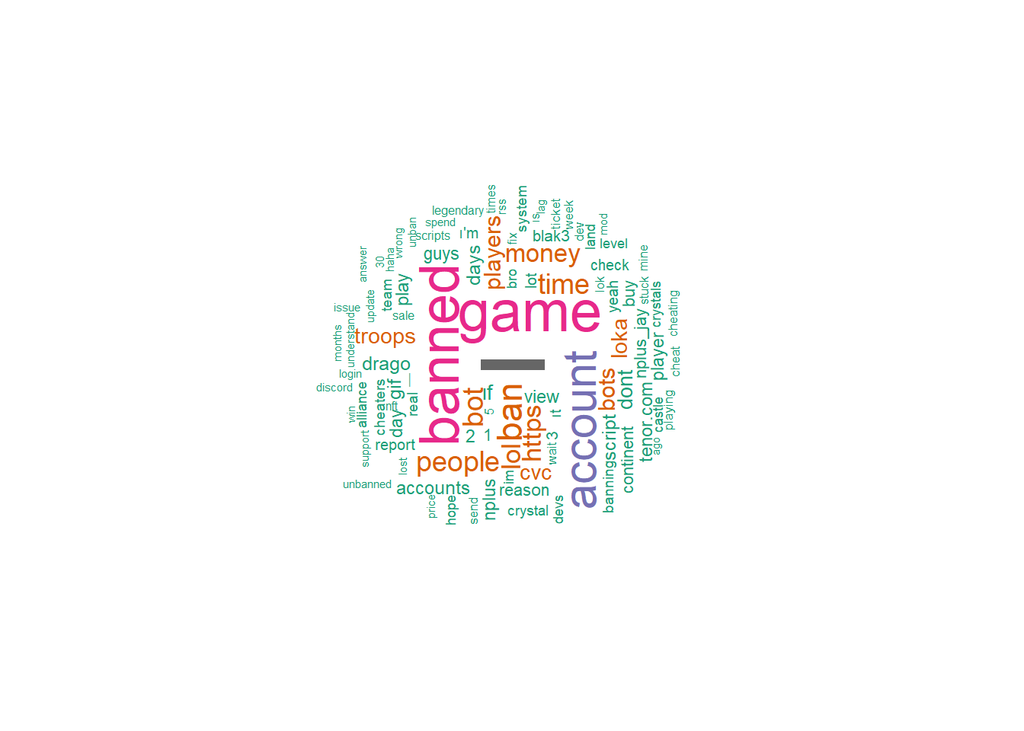

### Pozitif/Negatif kelimelerin ayrıldığı kelime bulutu

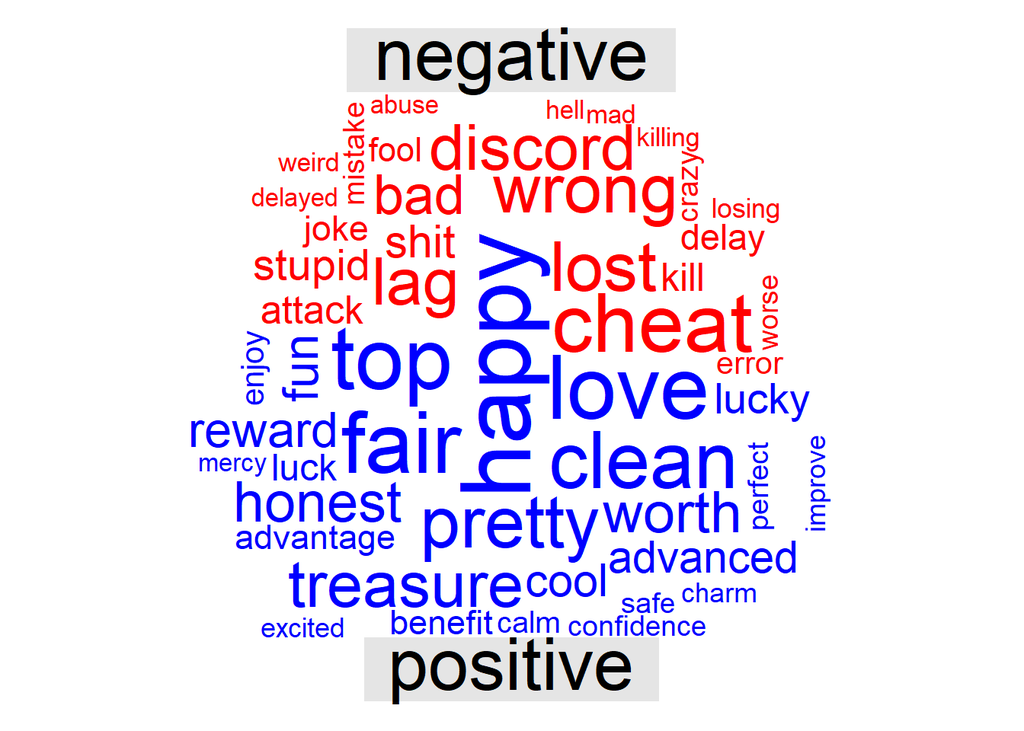

```r
sentiments<-cleandata %>%inner_join(get_sentiments("bing"))%>% dplyr:: count(word,sentiment,sort=TRUE)
head(sentiments)
```

```
## # A tibble: 6 x 3
##   word      sentiment     n
##   <chr>     <chr>     <int>
## 1 cheat     negative    102
## 2 stuck     negative     93
## 3 cheating  negative     88
## 4 legendary positive     86
## 5 lost      negative     83
## 6 wrong     negative     83
```

```r
sentiment_pos<-subset(sentiments,sentiment=="positive")
sentiment_neg<-subset(sentiments,sentiment=="negative")
```

```r
set.seed(2022)
positive_score<-aggregate(n~sentiment,data=sentiment_pos,sum)
negative_score<-aggregate(n~sentiment,data=sentiment_neg,sum)
ratio<-(positive_score$n/negative_score$n) ## %53 pozitif
ratio
```

```
## [1] 0.5350112
```